# Final Exam 2

# Instructions

1. Only complete the sections for which you want a better score. (Complete all questions within a section.)
2. After completing the exam:
   - Delete any sections that you did not complete.
   - Save the exam as final-exam-2.rmd and final-exam-2.html in the 99-final-exam folder of your Probability and Inference Portfolio repo.
   - Push your repo.

# 1. Simulation

The Monte Hall problem is a classic game show. Contestants on the show where shown three doors. Behind one randomly selected door was a sportscar; behind the other doors were goats.

At the start of the game, contestants would select a door, say door A. Then, the host would open either door B or C to reveal a goat. At that point in the game, the host would ask the contestant if she would like to change her door selection. Once a contestant decided to stay or change, the host would open the choosen door to reveal the game prize, either a goat or a car.

In this problem, consider a **modified** version of the Monte Hall problem in which the number of doors is **variable**. Rather than 3 doors, consider a game with 4 or 5 or 50 doors. In the modified version of the game, a contestant would select an initial door, say door A. Then, the host would open **one** of the remaining doors to reveal a goat. At that point in the game, the host would ask the contestant if she would like to change her door selection. Once a contestant decided to stay or change, the host would open the choosen door to reveal the game prize, either a goat or a car.

Consider two strategies:

1. Always stay with the first door selected.
2. Always switch to the unopened door.

**C.** The function `game` below plays a single game of Monte Hall. The function returns a vector of length two, the first element is the prize under strategy 1 and the second element is the prize under strategy 2. The function has a single input parameter, N, which is the number of doors in the game.

Use the `game` function to estimate the probability that both strategies result in a goat. Let **N=4**.

**HINT:** Create an Rx2 array, and store the results of each game as a row in the array. Create a cross tabulation of the winnings from strategy 1 and strategy 2.

```r
game <- function(N){
  if(N<3) stop("Must have at least 3 doors")
  prize <- sample(c(rep("goat",N-1),"car"), N)
  guess <- sample(1:N,1)
  game <- data.frame(door = 1:N, prize = prize, stringsAsFactors = FALSE) %>%
    mutate(first_guess = case_when(
      door == guess ~ 1
      , TRUE ~ 0
    )) %>%
    mutate(potential_reveal = case_when(
        first_guess == 1 ~ 0
      , prize == "car" ~ 0
      , TRUE ~ 1
    )) %>%
    mutate(reveal = 1*(rank(potential_reveal, ties.method = "random") == 3)) %>%
    mutate(potential_switch = case_when(
      first_guess == 1 ~ 0
      , reveal == 1 ~ 0
      , TRUE ~ 1
    )) %>%
    mutate(switch = 1*(rank(potential_switch, ties.method = "random") == 3))
  c(game$prize[game$first_guess == 1], game$prize[game$switch == 1])
}
```

```r
R=5000
strategy = array(NA, c(2, R))

set.seed(1)
R<-5000
strategy_1<-rep(NA,R)
strategy_2<-rep(NA,R)
for (i in 1:R){
  out<-game(N=4)
  strategy[1,i]<-out[1]
  strategy[2,i]<-out[2]
}
mean(strategy[1,]=='goat'&strategy[2,]=='goat')
```

```
## [1] 0.3772
```

**B**. Continuing from part **C**, what is the probability that at least one of the strategies results in winning a car?

**HINT:** Use the cross tabulation from the previous part to calculate this probability.

```r
mean(strategy[1,]=='car'|strategy[2,]=='car')
```

```
## [1] 0.6228
```

**A**. Communicate the precision of your simulated probability in part **B** by calculating a **99%** confidence interval.

**HINT:** Use the CLT short cut.

```r
result<-prop.test(sum(strategy[1,]=='car'|strategy[2,]=='car'),R,conf.level = .99)
result
```

```
##
##  1-sample proportions test with continuity correction
##
## data:  sum(strategy[1, ] == "car" | strategy[2, ] == "car") out of R, null probability 0.5
## X-squared = 301.11, df = 1, p-value < 2.2e-16
## alternative hypothesis: true p is not equal to 0.5
## 99 percent confidence interval:
##  0.6048914 0.6403813
## sample estimates:
##      p
## 0.6228
```

When I use the CLT short cut to simulate my result, we can find that the 99% Ci is (0.6048914,0.6403813), the sumulated probability is 0.6228 is Ci interval and the ci interval difference is only 0.0355, which is a very tight result. Thus I believe that the simulated probability I did is high precision.

# 4. Continuous Distributions

Let X be distributed as a mixture normals. The `r`, `p`, and `d` functions are below. (This is our old friend `f3` from deliverable 5.)

```r
rf3 <- function(N){
  G <- sample(0:2, N, replace = TRUE, prob = c(5,3,2))
  (G==0)*rnorm(N) + (G==1)*rnorm(N,4) + (G==2)*rnorm(N,-4,2)
}

pf3 <- function(x){
  .5*pnorm(x) + .3*pnorm(x,4) + .2*pnorm(x,-4,2)
}

df3 <- function(x){
  .5*dnorm(x) + .3*dnorm(x,4) + .2*dnorm(x,-4,2)
}
```

Let Y be distirbuted as another mixture of normals. The `r`, `p`, and `d` functions are below. (This is a slightly different distribution.)

```r
rf4 <- function(N){
  G <- sample(0:2, N, replace = TRUE, prob = c(2,3,5))
  (G==0)*rnorm(N) + (G==1)*rnorm(N,4) + (G==2)*rnorm(N,-4,2)
}

pf4 <- function(x){
  .2*pnorm(x) + .3*pnorm(x,4) + .5*pnorm(x,-4,2)
}

df4 <- function(x){
  .2*dnorm(x) + .3*dnorm(x,4) + .5*dnorm(x,-4,2)
}
```

**C.** What is the .9 quantile of X?

```r
R=5000

quantile(rf3(R),0.9)
```

```
##     90%
## 4.47548
```

**B.** Suppose that X is the distribution of a biomarker when a patient is healthy. Suppose Y is the distribution of the same biomarker when a patient has a genetic condition.

Calculate P(genetic condition is present | biomarker = 0) under the assumption that P(genetic condition) = 0.1.

```r
p<-df4(0)*0.1/(df3(0)*0.9+df4(0)*0.1)
p
```

```
## [1] 0.04816794
```

**A.** Generate a plot of P(genetic condition is present | biomarker = B). Let B length range from -6 to 6.

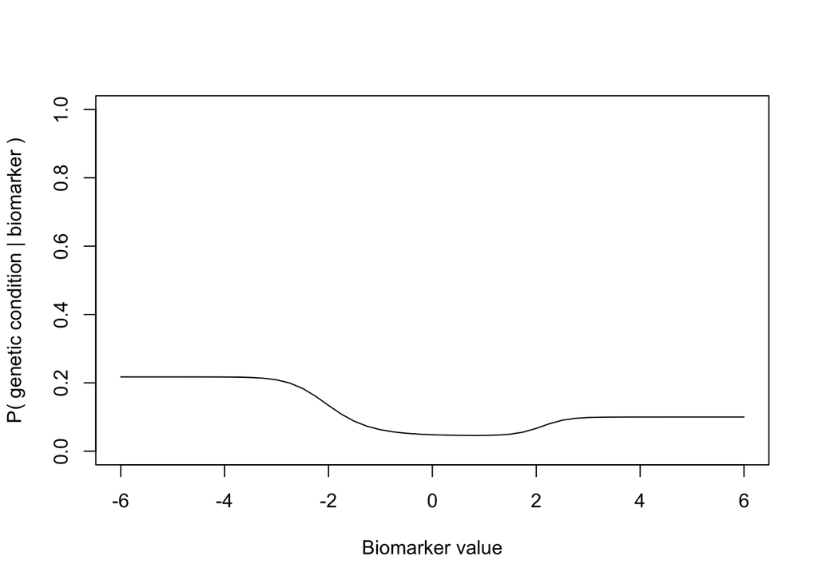

```r
B <- seq(-6, 6, by = .25)
prob_genetic_condition <- df4(B)*0.1/(df3(B)*0.9+df4(B)*0.1)
plot.new()
plot.window(xlim = c(-6,6), ylim = c(0,1))
lines(B, prob_genetic_condition)
axis(1)
axis(2)
box()
title(xlab = "Biomarker value", ylab = "P( genetic condition | biomarker )")
```